# Variation in aboveground tree live biomass in a central Amazonian Forest: Effects of soil and topography - ScienceDirect

- [View **PDF**](https://www.sciencedirect.com/science/article/pii/S0378112706004361/pdfft?md5=3e7bcafa8040eb9c21db6b34003e9c07&pid=1-s2.0-S0378112706004361-main.pdf)

## [Forest Ecology and Management](https://www.sciencedirect.com/journal/forest-ecology-and-management)

[Volume 234, Issues 1–3](https://www.sciencedirect.com/journal/forest-ecology-and-management/vol/234/issue/1), 1 October 2006, Pages 85-96

# Variation in aboveground tree live biomass in a central Amazonian Forest: Effects of soil and topography

https://doi.org/10.1016/j.foreco.2006.06.024[Get rights and content](https://s100.copyright.com/AppDispatchServlet?publisherName=ELS&contentID=S0378112706004361&orderBeanReset=true)

Abstract

We used forest inventories, conducted in seventy-two 1-ha permanent plots to assess the variation in tree and palm aboveground live biomass (AGLB), and its relation with soil gradients (texture and nutrients) and topography (altitude and slope). Our plots, located at Reserva Florestal Adolpho Ducke, a 10,000 ha reserve in central Amazonia, near the city of Manaus, were systematically spread over 64 km<sup>2</sup>. The plots were long (250 m) and narrow (up to 40 m), following elevational contours. Chemical and physical soil analyses were undertaken using topsoil samples, collected in each plot. The plots covered a soil textural gradient ranging from 8% to 98% percent of sand, slopes varying from 0.5° to 27°, and the maximum difference of altitude among plots was 70 m, ranging from 39 to 109 m a.s.l. The mean total AGLB (palm + trees) for stems over 1 cm diameter breast height (dbh = 1.3 m), was 327.8 Mg/ha (ranging from 210.9 to 426.3) and was similar to other studies in the region. We found a two-fold variation in total AGLB estimates among plots, with soil or topography explaining around 20% of this variation. AGLB was positively related to either a soil textural gradient (represented by the percentage of clay) or altitude, but was insensitive to slope. Although slope had no detectable effect on the mean variation of AGLB per plot, it explained 14% of the AGLB in understory and emergent trees. On slopes, AGLB is concentrated mostly in tree classes of small size (1 ≤ dbh < 10 cm), whereas in flat areas, most of the biomass is concentrated in a few big trees. When considering palms and trees separately, we found that tree biomass tended to increase in clay-rich soils (mostly located in high areas), whereas palm biomass was higher in sandy soils (low slopes and bottomlands). This study shows that forests in central Amazonia grow in a heterogeneous environment in relation to soil and topography, and this heterogeneity seems to be in part responsible for differences in structure and AGLB accumulation. In the forest around Manaus, topography can be used to predict aboveground live biomass as an alternative to soil variables, with similar predictive power. Topographic variables can be easily assessed using satellite imagery and could improve current estimates of carbon stocks over large areas in the Amazon.

## Keywords

Aboveground tree live biomass

Soil

Topography

Central Amazonia

## 1. Introduction

Tropical forest biomass estimates are a useful way to assess the forest carbon stocks and emissions to the atmosphere during deforestation and changes in land cover (Fearnside, 1996, Malhi and Grace, 2000). Carbon content in plant tissue is approximately, half of the dry weight of aboveground live biomass (Higuchi et al., 1998, Malhi and Grace, 2000), which is strongly correlated with trunk diameter; therefore it is possible to use regressions models to convert trunk diameter data into an estimate of biomass (Brown, 1997).

Knowing the spatial variation of forest biomass is important because the emissions of carbon from deforestation are determined by the biomass of the forest actually deforested, not necessarily by the average biomass for a region (Houghton, 2005). Therefore, it is essential to describe the variation of biomass at multiple scales. Biomass varies across broad environmental gradients of moisture and temperature, and it varies at fine scales as a result of natural disturbances (Houghton, 2005). Tropical forests exhibit large spatial variability in tree biomass (e.g. Laurance et al., 1999, Chave et al., 2001, Chave et al., 2003) but this variation is poorly documented (Houghton, 2005). For example, most studies recognize differences in the aboveground biomass among different forest types in the Amazon (e.g. Houghton et al., 2001), but there is little information to evaluate the variation in carbon stocks within a single forest type (for an exception, see Laurance et al., 1999). Most available data were obtained either from small plots (≤1 ha, see examples in Brown and Lugo, 1992), which are not representative, or very large plots (e.g. 50 ha in Chave et al., 2003), which generally lack replicates and are rarely randomly located in the landscape (Brown and Lugo, 1992, Clark and Clark, 2000, Keller et al., 2001, Clark, 2002, Chave et al., 2004). Furthermore, there is a tendency for researchers to select ‘attractive’ forests (Sheil, 1995) or to avoid naturally disturbed ones (Körner, 2003). Consequently, these plots may not be useful to assess all the conditions that affect forest biomass. One approach is to replicate the measurements in many plots of the same forest, to encompass the environmental variability across the landscape (Clark and Clark, 2000, Chave et al., 2004).

The first landscape-scale study addressing AGLB distribution in central Amazonia found a two-fold variation in biomass estimates across 1000 km<sup>2</sup> of terra-firme forest (Laurance et al., 1999). Around 30% of the AGLB variation was explained by soil factors, supporting the idea that biomass accumulation in tropical forest is related to soil quality. However, the plots used by Laurance et al. (1999) were square in shape and, although they covered a wide range of edaphic conditions, were not completely representative of the area. The location of some of these plots were biased because, in smaller reserves (1 and 10 ha), the plots were placed to avoid streams (Fearnside, pers. comm.). Additionaly, square 1-ha plots may include a wide variation in topographic and edaphic variables, where part of the plot may be on sandy soil and another on heavy clay.

Magnusson et al. (2005) developed a method to evaluate floristic variation in long, thin plots that follow topographic contour lines. This method was designed to minimize altitudinal variation within plots, increasing the precision of estimates of predictor variables. Long, thin plots, however, have a high perimeter–area ratio, which could lead to errors in the inclusion of individual trees, and reduce the precision of biomass estimates. Therefore, it is important to determine whether the new methodology, which permits the cost-efficient inclusion of trees of all size classes, produces biomass estimates similar to those from conventional square 1-ha plots.

In central Amazonia, soil characteristics are often related to local altitude, i.e. to the position along a soil catena (Chauvel et al., 1987). Soil maps of central Amazonia are very imprecise, but altitude can be determined from topographic maps, or using digital elevation models (DEM) derived from SRTM radar (shuttle radio topographic mission), with a high degree of confidence. Therefore, we tested whether altitude can be used as a surrogate for soil characteristics to predict AGLB.

In this paper, we describe the variation in AGLB in 72 1-ha plots spanning 64 km<sup>2</sup> of old growth *terra-firme* forest in Reserva Florestal Adolpho Ducke. The permanent plots installed at Reserva Ducke (Magnusson et al., 2005) offer a unique opportunity to evaluate the distribution of AGLB in relation to topographic and edaphic variables over a meso-scale landscape. The sampling method was designed to replicate the AGLB measurements in plots of the same forest. The main concern was to delineate sample units that maintain similar terrain features by keeping elevation and soil characteristics relatively constant within each plot. The plots were distributed systematically, and represent the topographic and edaphic variation typical of the geological formation *Alter do Chão* underlying about 25% of central Amazonia (Sombroek, 2000). Detailed data on soil chemistry and texture offer a unique opportunity to assess fine-scale variability in central Amazonian soils and to investigate the potential significance of this variability to natural vegetation, influencing the amount of AGLB in each plot. Specifically, we addressed the following questions:

- (1)

  Do soil and topography explain the variation in tree and/or palm AGLB estimates at Reserva Ducke?
- (2)

  Based on the strong correlation between soil texture and altitude, can we use only topographic variables to predict AGLB spatial variation in central Amazonia?
- (3)

  Do soil and topography affect different forest components, such as tree and palm AGLB in the same way?
- (4)

  Do all tree size classes respond in the same way to topography or are the effects related to size class?

## 2. Materials and methods

### 2.1. Study site

This research was conducted at Reserva Florestal Adolpho Ducke, Manaus, Amazonas, Brazil (02°55′S, 59°59′W) between December 2000 and February 2003. The reserve covers 10,000-ha (10 km × 10 km) of old-growth forest located 26 km north-east of Manaus. The vegetation is classified as *terra-firme* forest with a closed canopy, and an understory covered with abundant acaulescent palms (Ribeiro et al., 1999). Canopy height of trees is generally 30–37 m with individuals that reach 40–45 m (Ribeiro et al., 1999). Average annual rainfall at this site is about 2300 mm, with a distinct dry season during July–September with usually less than 100 mm of rain per month during 3 months (Marques-Filho et al., 1981). Mean monthly temperature is stable throughout the year, at around 26 °C (Marques-Filho et al., 1981).

The reserve lies within the geological formation *Alter do Chão*. The soils are derived from Tertiary fluvio-lacustrine deposits, which are sediments derived from the deeply weathered Precambrian Guianan and Brazilian Shields (Chauvel et al., 1987, Sombroek, 2000). The reserve is covered mostly by Oxisols (allic yellow latosols in the Brazilian system) on the plateaus, Ultisols (podzol in the Brazilian system) on slopes, and Spodosols associated with small streams in small valley bottoms (Chauvel et al., 1987, Bravard and Righi, 1989). These soils are typically acidic and very low in nutrients, such as phosphorus, calcium, and potassium (Chauvel et al., 1987). Intensive studies at Reserva Ducke have shown that the clay content of the top 5 cm of soil is highly correlated with altitude (Pearson correlation = 0.94; R. Luizão, unpublished data). When moving from a plateau to a valley, clay content decreases strongly and sand content increases (Chauvel et al., 1987).

The topography of the reserve is undulating with a dense drainage network forming a pattern of plateaus and valleys with a maximum altitudinal difference of about 100 m (from 40 to 140 m a.s.l.) (Ribeiro et al., 1999). A ridge that runs from north to south through the middle of the reserve separates two major watersheds. Streams to the east flow to tributaries of the Amazon River, and those to the west flow to the Negro River.

### 2.2. Sampling design

A grid of 18 8 km trails covers an area of 64 km<sup>2</sup> within Reserva Ducke. We used this grid to systematically distribute permanent plots in the reserve. We established eight plots on each of the nine east-west trails, (72 plots total). All plots were at least 1 km from the edge of the reserve and from one another.

Each permanent plot was 250 m long and was established following the topographic contour. The advantage of this design is that narrow plots following contour lines tend to keep soil conditions homogeneous, given that soil types vary with altitude (Chauvel et al., 1987). By orienting the plots to follow the altitudinal contours, we were able to use long thin plots to capture within-habitat variation in vegetation, while minimizing within-plot variation in topographic variables (Magnusson et al., 2005).

Within plots, trees were mapped, and their diameters at breast height (dbh) were measured (see biomass estimates for details). We established a hierarchical design to sample trees and palms. Trees with dbh ≥ 30 cm were sampled in 1-ha (40 m × 250 m). Sub-samples of 0.5 ha (20 m × 250 m) and 0.1 ha (4 m × 250 m) were used to sample trees with 10 cm ≤ dbh < 30 cm and 1 cm ≤ dbh < 10 cm, respectively. To map trees and define the area of the plot we used the horizontal area. Although most researchers define plot area using a slope correction, we used horizontal area to provide the same available area for tree crowns, independent of the topography. Plots that have 1-ha of ground area, in steep areas, will have less than 1-ha available for tree crowns (horizontal area). Another advantage of using a horizontal area is that it facilitates transfer of the limits of the plot to maps or satellite imagery.

### 2.4. Soil data

A total of 23 soil attributes were recorded from soil-surface samples (0–5 cm) collected within each plot. The field and laboratory methods used for soil analyses are presented in detail in Mertens (2004), and are briefly summarized here. Soil textural analyses were conducted at INPA (National Institute for Research in the Amazon) and nutrients analyses were conducted at EMBRAPA (Brazilian Agricultural Research Corporation) soil laboratories.

To assess soil properties, a composite sample was made from six topsoil (0–5 cm) cores taken every 50 m along the centerline of the plot. Composite samples for each plot were oven-dried, cleaned by removing stones and fine roots, and passed through a 2 mm sieve. The hydrometer method was used to estimate percent of clay, silt, and sand (<0.002, 0.002–0.05, and 0.05–2 mm, respectively) (Mathieu and Pieltain, 1998). Soil acidity in distilled H<sub>2</sub>O was measured with a pH meter. Total N was determined by wet oxidation (Kjeldahl method) converting organic N to ammonium (NH<sub>4</sub><sup>+</sup>) for measurement. Total organic C was determined by wet oxidation in an acid dichromate solution followed by titration with 0.5N FeSO<sub>4</sub> and *o*-phenalphthroline as indicator. The determination of available phosphorus was done by the ammonium molybdate–ascorbic acid method (Murphy and Riley, 1962). The blue color complex formed was read photometrically at 712 nm. K<sup>+</sup>, Na<sup>+</sup>, Cu, Fe, Mn<sup>2+</sup>, Zn<sup>+</sup> were extracted by the Mehlich 1 method (Nelson et al., 1953) and measured by atomic absorption. Ca<sup>2+</sup> and Mg<sup>2+</sup> were also measured by atomic absorption spectrophotometry after extraction with a concentrated 1N KCl solution. The concentrations of Al<sup>3+</sup> and H<sup>+</sup> in the soil were determined by titration with 0.025N NaOH solution containing 1% of phenolphthalein as indicator. Cation measures included cation exchange capacity (CEC), which is the sum of K<sup>+</sup>, Ca<sup>2+</sup>, Mg<sup>2+</sup>, Na<sup>+</sup>, Al<sup>3+</sup> + H<sup>+</sup>; and total exchangeable bases (TEB), which is the sum of K<sup>+</sup>, Ca<sup>2+</sup>, Mg<sup>2+</sup> + Na<sup>+</sup>. Cations were extracted in a 1 M KCl solution at unbuffered pH of the soil (EMBRAPA, 1997).

### 2.5. Biomass estimates

We estimated the aboveground dry biomass (AGLB) of live trees and palms for each of the 72 plots. AGLB was estimated by carefully measuring (to the nearest 1 mm) the diameters of trees ≥ 1 cm at breast height (dbh = 1.3 m above the ground). Protocols for diameter measurements depended on tree size. For individuals < 6 cm in diameter, maximum stem diameter was measured with calipers. Boles > 6 cm in diameter were measured with a fabric diameter tape (Forestry Suppliers, model 283D). When the point of measurement (1.3 m above the ground) was affected by buttresses or major stem deformities, measurements were taken 50 cm above any deformity. Measurements of dbh were converted to biomass estimates with a combination of allometric models developed for local forests, depending on the life form and diameter class (Table 1).

Table 1. Allometric equations used to estimate tree and palm aboveground dry biomass (AGLB, kg ha<sup>−1</sup>)

| Life form | Allometric equations |
| --- | --- |
| Trees |  |
| dbh ≥ 1 cm and dbh < 5 cm<sup>a</sup> | AGLB = exp(−1.7689 + 2.3770 × ln(dbh)) |
| dbh ≥ 5 cm and dbh < 20 cm<sup>b</sup> | AGLB = exp(−1.754 + 2.665 × ln(dbh)) × 0.6<sup>c</sup> |
| dbh ≥ 20 cm<sup>b</sup> | AGLB = exp(−0.151 + 2.170 × ln(dbh)) × 0.6<sup>c</sup> |
| Palms |  |
| dbh ≥ 1 cm<sup>d</sup> | AGLB = exp(−6.3789 − 0.877 × ln(1/dbh<sup>2</sup>) + 2.151 × ln(*H*) |

The equations were based on diameter at breast height (dbh, cm) and/or height (*H*, m).

**a**

Nascimento and Laurance (2002).

**b**

Higuchi et al. (1998).

**c**

The Higuchi et al. (1998) equations, in contrast to the others used in this study, provide wet weight biomass estimates. To correct for that, we assumed that dry weight is 60% of wet weight and we multiply the values obtained by 0.6 to provide dry biomass estimates (Higuchi et al., 1998).

**d**

Saldarriaga et al. (1988).

The allometric equation used to estimate biomass of arborescent palms is based on dbh and height, but we did not directly measure height. Palm dbh was measured only for individuals with exposed stems, after removal of any old petiole bases. For palm height, we defined a species-specific value based on species descriptions in the “Palm Florula of Reserva Ducke” (Henderson and Scariot, 1993). First, we calculated the median dbh of each species measured in the field and compared this with literature data. If the median dbh of our sample for the target species was coincident with the minimum dbh registered in the Florula, we used the minimum height registered for this species as the value of height for all individuals of this species. When the median dbh of our species sample was the maximum dbh recorded in the Florula, we use the maximum height for biomass estimates.

### 2.6. Data analysis

We used Principal Components Analysis (PCA) as the ordination method to describe major gradients in the soil, using a subset of 14 variables (see Table 2 for a list of the soil variables recorded in each plot). We initially conducted all analyses including and excluding carbon and nitrogen, because these are mainly derived from vegetation, and including them in analyses to predict vegetation characteristics would be circular reasoning. Nutrient cations in the topsoil are also derived from vegetation as the soil at greater depth in the Manaus area contains almost no nutrient cations. However, available carbon and nitrogen are cycled directly from atmosphere to soil, mainly thorough plants and are not derived from mineral soil at any depth. The addition of these elements had little effect on the PCA axes. Therefore, we only present the results excluding carbon and nitrogen.

Table 2. Summary statistics of soil and topographic variables measured in 72 permanent plots at Reserva Ducke

| Variables | Min | Max | Mean | S.D. |
| --- | --- | --- | --- | --- |
| Topography |  |  |  |  |
| Slope (°) | 0.50 | 27.00 | 9.99 | 7.48 |
| Altitude (a.s.l.) | 39.00 | 109.00 | 75.61 | 20.08 |
| Soil texture |  |  |  |  |
| Clay (%) | 1.62 | 87.74 | 47.44 | 33.32 |
| Silt (%) | 0.29 | 14.15 | 3.37 | 1.99 |
| Sand (%) | 8.00 | 98.09 | 49.15 | 33.84 |
| Acidity |  |  |  |  |
| pH in water | 3.45 | 4.87 | 4.04 | 0.27 |
| Carbon |  |  |  |  |
| Organic C (g/kg) | 7.31 | 73.03 | 28.21 | 12.27 |
| Primary nutrients |  |  |  |  |
| N (g/kg) | 0.52 | 3.16 | 1.79 | 0.71 |
| P (mg/dm<sup>3</sup>) | 1.00 | 12.00 | 3.21 | 2.28 |
| K (mg/dm<sup>3</sup>) | 12.00 | 52.00 | 24.64 | 7.89 |
| Secondary nutrients |  |  |  |  |
| Ca<sup>2+</sup> (c.mol/dm<sup>3</sup>) | 0.01 | 0.25 | 0.05 | 0.04 |
| Mg<sup>2+</sup> (c.mol/dm<sup>3</sup>) | 0.01 | 0.12 | 0.05 | 0.03 |
| Na<sup>2+</sup> (mg/dm<sup>3</sup>) | 5.00 | 24.00 | 11.96 | 3.85 |
| Micronutrients |  |  |  |  |
| Cu<sup>+</sup> (mg/dm<sup>3</sup>) | 0.00 | 0.40 | 0.15 | 0.12 |
| Fe<sup>2+</sup> (mg/dm<sup>3</sup>) | 6.00 | 449.00 | 164.07 | 104.45 |
| Mn<sup>2+</sup> (mg/dm<sup>3</sup>) | 0.10 | 1.90 | 0.76 | 0.44 |
| Zn<sup>2+</sup> (mg/dm<sup>3</sup>) | 0.23 | 2.94 | 0.52 | 0.34 |
| Other ions |  |  |  |  |
| Al<sup>3+</sup> (c.mol/dm<sup>3</sup>) | 0.56 | 2.88 | 1.68 | 0.52 |
| Al<sup>3+</sup> + H<sup>+</sup> (c.mol/dm<sup>3</sup>) | 5.06 | 15.11 | 9.42 | 2.37 |
| Cations |  |  |  |  |
| Total exchangeable bases (TEB) | 25.23 | 111.26 | 52.87 | 18.22 |
| Cation exchange capacity (CEC) | 90.09 | 338.95 | 204.22 | 55.65 |

To test the effects of soil gradients and topography on biomass estimates, we used several multiple regression analyses. Pearson correlations were used to test for colinearity between soil gradients (PCA axis) and topography. As altitude was highly correlated with the first PCA axis, we excluded it from analyses involving soils. We ran separate regressions for palms and other trees in order to assess the individual effects of the soil and topography on each of these forest components. We also ran multiple regressions using only the topographic variables slope and altitude to test whether they could predict variation in tree and/or palm biomass estimates. We used the SYSTAT 8.0 package for all analyses (Wilkinson, 1990).

## 3. Results

### 3.1. Topography and soil gradients

Soil and topographical variables varied widely among plots (Table 2). The clay content of superficial soil varied from 1.6% to 87.7%. Clay soils were more frequent in the eastern watershed of the reserve, whereas soils in 60% of plots in the western watershed contained 50% or more sand. Altitude varied from 39 to 109 m a.s.l., and slope within plots ranged from 0.5° to 27°.

The ordination analysis revealed three main soil gradients in the study area (Table 3). Axis 1, which captured 34% of the total variation in the dataset, described a gradient between plots with high clay content (and higher K<sup>+</sup>, Mg<sup>2+</sup>, Na<sup>+</sup>, Al<sup>3+</sup> and Al<sup>3+</sup> + H<sup>+</sup>), and those with high sand content. Axis 2, which explained 23% of the variation, mainly described a continuum in soil pH, with more acidic sites having higher Fe<sup>2+</sup> and Al<sup>3+</sup>, and less P, K<sup>+</sup>, Ca<sup>2+</sup>, Mg<sup>2+</sup>, Mn<sup>2+</sup>, and Zn<sup>2+</sup>. Axis 3 explained 8% of the variation and described a gradient in silt and P.

Table 3. Correlations of 14 topsoil variables (0–5 cm) and three ordination axes produced by Principal Components Analysis

| Variables | Axis 1 | Axis 2 | Axis 3 | Altitude | Slope |
| --- | --- | --- | --- | --- | --- |
| Clay | 0.83 | −0.32 | 0.09 | 0.94 | −0.27 |
| Silt | 0.29 | −0.12 | −0.78 | 0.25 | 0.07 |
| $pH(H2O)$ | −0.54 | 0.59 | 0.07 | −0.37 | −0.01 |
| P | −0.27 | 0.56 | −0.52 | −0.45 | −0.08 |
| K<sup>+</sup> | 0.66 | 0.65 | −0.10 | 0.38 | −0.40 |
| Ca<sup>2+</sup> | 0.28 | 0.70 | −0.12 | 0.05 | −0.25 |
| Mg<sup>2+</sup> | 0.44 | 0.76 | 0.15 | 0.18 | −0.32 |
| Na<sup>+</sup> | 0.80 | 0.07 | −0.11 | 0.60 | −0.22 |
| Cu<sup>+</sup> | 0.38 | −0.14 | 0.09 | 0.12 | 0.06 |
| Fe<sup>2+</sup> | 0.55 | −0.56 | −0.08 | 0.48 | 0.34 |
| Mn<sup>2+</sup> | 0.42 | 0.57 | 0.32 | 0.14 | −0.29 |
| Zn<sup>2+</sup> | 0.01 | 0.48 | 0.04 | −0.12 | −0.17 |
| Al<sup>3+</sup> | 0.91 | −0.25 | 0.01 | 0.74 | −0.27 |
| Al<sup>3+</sup> + H<sup>+</sup> | 0.92 | 0.11 | 0.04 | 0.63 | −0.37 |
| Altitude<sup>a</sup> | 0.76 | −0.23 | 0.06 | – | – |
| Slope<sup>a</sup> | −0.28 | −0.33 | −0.11 | – | – |
| Variation explained (%) | 34.12 | 22.97 | 7.67 | – | – |

**a**

Altitude and slope were not included in soil ordinations but we tested the correlation between these variables and each soil variable alone and PCA axes.

Soil gradients and topography were related. Axis 1 was correlated to altitude (*r*<sup>2</sup> = 0.76; *P* < 0.001), but was not correlated to slope (*r*<sup>2</sup> = −0.28; *P* = 0.18). The soil variables associated with this axis were also correlated with altitude (data not shown). Axis 2 reflects mainly the soil fertility and was not correlated with altitude (*r*<sup>2</sup> = −0.23; *P* = 0.57), but was moderately correlated with slope (*r*<sup>2</sup> = −0.33; *P* = 0.04). None of the variables associated with the axis 2 were individually correlated with slope (data not shown).

### 3.2. Variation in tree and palm density and AGLB

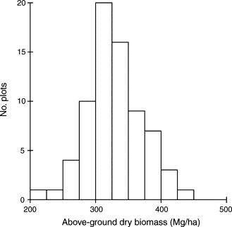

1. [Download : Download full-size image](https://ars.els-cdn.com/content/image/1-s2.0-S0378112706004361-gr1.gif)

Fig. 1. Frequency distribution of aboveground dry biomass of live trees in seventy-two 1-ha plots in central Amazonia.

Table 4. Mean AGLB of trees and number of individuals of different diameter size classes in seventy-two 1-ha plots at Reserva Ducke, Manaus, Brazil

| Classes of dbh (cm) | AGLB (Mg/ha) | No. of individuals (ha<sup>−1</sup>) | % AGLB (Mg/ha) |
| --- | --- | --- | --- |
| ≥1, <10 | 19.4 (4.5) | 4307.5 (1085.2) | 6.1 (1.8) |
| ≥10, <20 | 45.8 (7.7) | 363.1 (63.0) | 14.3 (3.0) |
| ≥20, <30 | 63.5 (13.0) | 59.8 (11.9) | 19.7 (4.1) |
| ≥30, <40 | 58.0 (10.3) | 51.4 (9.0) | 17.9 (2.8) |
| ≥40, <50 | 45.9 (11.1) | 23.7 (5.8) | 14.1 (2.8) |
| ≥50, <60 | 32.4 (12.1) | 10.8 (3.9) | 9.8 (3.2) |
| ≥60, <70 | 20.7 (10.2) | 4.8 (2.4) | 6.0 (3.1) |
| ≥70 | 41.3 (27.3) | 4.5 (2.8) | 12.2 (7.1) |

Values are mean ± standard deviation (in parentheses).

The number of individuals and the biomass of palms varied greatly among plots (Appendix A). Around 3.4% of the individuals of each plot were palms (range: 0–18.7%). Most palms had dbh < 20 cm, but some species, such as *Mauritia flexuosa*, attained dbh greater than 50 cm. The mean palm biomass per plot was 2.1 Mg/ha, ranging from 0.0 to 21.2 Mg/ha. Most plots (76%) had palm biomass estimates lower than 2 Mg/ha. Palm biomass represented less than 1% of the total biomass in all plots combined, but palm biomass attained 10% of the total biomass in one plot.

### 3.3. Effects of soil gradients and topography on AGLB estimates

Around 20% of the spatial variation in AGLB estimates could be predicted from soil characteristics and slope (Table 5). AGLB was positively related to mineral soil PCA axis 1 (*t* = 3.13; *P* = 0.003) indicating higher biomass on more clay-rich substrates (Fig. 2). In all analyses, the plot with smallest AGLB estimates was a statistical outlier. This plot was located near a second order stream, characterized by poorly drained soil with predominance of large arborescent palms, such as *M. flexuosa* and *Oenocarpus bataua*. Excluding this outlier increased the predictive power of the regression: slope and soil gradients explained 29% of the AGLB variation (*F*<sub>4,66</sub> = 6.66, *P* < 0.001). PCA axis 1 was positively related to AGLB estimates (*t* = 3.23, *P* = 0.002).

Table 5. Results of multiple regressions relating aboveground dry biomass of live trees and/or palms to soil (PCA axes 1, 2 and 3) and topography (slope and altitude)

| Biomass components Empty Cell | *b*<sub>soil gradients</sub> PCA1 | *b*<sub>soil gradients</sub> PCA2 | *b*<sub>soil gradients</sub> PCA3 | *b*<sub>topography</sub> Slope | *b*<sub>topography</sub> Altitude | *R*<sup>2</sup> Empty Cell | *P* Empty Cell |
| --- | --- | --- | --- | --- | --- | --- | --- |
| Tree + palm | – | – | – | −0.206 | 0.347* | 0.21 | <0.000 |
|  | 0.353* | −0.017 | 0.021 | −0.231 | – | 0.22 | 0.002 |
| Palm | – | – | – | −0.310* | −0.429* | 0.18 | 0.001 |
|  | −0.247* | 0.694* | −0.070 | −0.006 | – | 0.55 | <0.001 |
| Tree | 0.364* | −0.074 | 0.026 | −0.224 | – | 0.22 | 0.002 |
|  | – | – | – | −0.174 | 0.372* | 0.21 | <0.001 |

The values represent the standard coefficient (*b*) associated with each predictor variable. This coefficient indicates the magnitude of the effect of the independent variable on AGLB estimate. **P* ≤ 0.005.

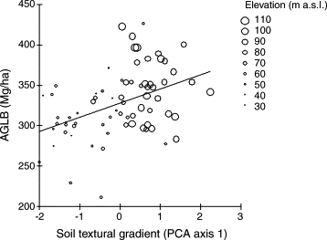

1. [Download : Download full-size image](https://ars.els-cdn.com/content/image/1-s2.0-S0378112706004361-gr2.gif)

Fig. 2. Relationship between PCA axis 1 and aboveground biomass of live trees in seventy-two 1-ha plots located at Reserva Florestal Adolpho Ducke. Positive values in the soil textural gradient represent plots with high clay soil. The size of the dots indicates the elevation of each plot. Higher AGLB estimates were found in plots with clay soils and these are generally located at higher elevation.

The trends observed for tree AGLB estimates excluding palms were very similar to the total AGLB estimates (Table 5). However, variation in palm AGLB did not follow the same pattern. Palm biomass was highly affected by soil and topography. The multiple regressions of PCA axes and slope explained 55% of the variation in palm AGLB. The slope of the terrain and the PCA axis 3 did not contribute significantly to the model, but the two soil variables (PCA axes 1 and 2) did (Table 5). The relation between PCA axis 1 and palm AGLB was negative, indicating that higher palm biomass was found in soils with more sand. However, the relationship between PCA axis 2 and palm AGLB was positive, indicating a strong positive effect of soil pH, P and or base availability on palm AGLB. The model using only topographic variables explained 18% of the variation in palm AGLB (Table 5). Palm biomass was negatively related to altitude (*t* = −3.71, *P* < 0.001) and slope (*t* = −2.68, *P* = 0.009).

### 3.4. Effects of topography on AGLB by tree size class

The effects of topography on AGLB estimates depended on tree size class. Slope affected mainly the AGLB of small (1 cm ≤ dbh < 10 cm) and big trees (dbh ≥ 70 cm). The AGLB of small trees increased with slope, but the opposite trend occurred for emergent trees (Table 6). Slope alone explained 14% of the AGLB variation in trees 1 cm ≤ dbh < 10 cm (*F*<sub>1,70</sub> = 11.19; *P* = 0.001) or dbh ≥ 70 cm (*F*<sub>1,70</sub> = 11.18; *P* = 0.001) (Fig. 3). AGLB estimates of trees with 30 cm ≤ dbh < 40 cm were not affected by topography. Slope did not explain the spatial variation in AGLB of canopy trees (40 cm ≤ dbh < 60 cm), but altitude positively affected their biomass. The size class (40 cm ≤ dbh < 50 cm) with small canopy trees was the most affected by topography (*F*<sub>2,69</sub> = 11.04, *P* < 0.001). Altitude (*t* = 3.75, *P* < 0.001) and slope (*t* = −1.36, *P* = 0.18) explained 24% of the AGLB variation in this tree size class, but altitude alone explained 22% (Fig. 4).

Table 6. Results of multiple regressions relating AGLB estimates of different tree size class to topography (slope and altitude)

| Size class | Slope | Altitude | *F* | *P* | *R*<sup>2</sup> |
| --- | --- | --- | --- | --- | --- |
| ≥1, <10 | (0.41)** | NS | 5.99 | 0.004 | 0.15 |
| ≥10, <20 | (0.31)* | (0.31)* | 5.01 | 0.009 | 0.13 |
| ≥20, <30 | (0.29)* | NS | 2.76 | 0.070 | 0.07 |
| ≥30, <40 | NS | NS | 1.86 | 0.163 | 0.05 |
| ≥40, <50 | NS | (0.42)** | 11.04 | <0.000 | 0.24 |
| ≥50, <60 | NS | (0.26)* | 2.97 | 0.057 | 0.08 |
| ≥60, <70 | NS | NS | 3.21 | 0.047 | 0.09 |
| ≥70 | (−0.35)** | NS | 5.62 | 0.005 | 0.14 |

The values in parentheses represent the standard coefficient (*b*) of variables that contributed significantly to the model. This coefficient indicates the magnitude of the effect of the independent variable on AGLB estimate. NS = *P* > 0.05; **P* < 0.05; ***P* < 0.005.

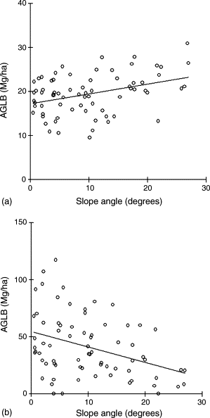

1. [Download : Download full-size image](https://ars.els-cdn.com/content/image/1-s2.0-S0378112706004361-gr3.gif)

Fig. 3. Effects of slope (°) on aboveground live biomass (AGLB, Mg/ha) of (a) understory and sub-canopy trees (1 cm ≤ dbh < 10 cm) and (b) emergent trees (dbh ≥ 70 cm). The lines on parts a and b represent linear regressions (AGLB = 17.1 + 0.23 slope, *r*<sup>2</sup> = 0.14, *F*<sub>1,70</sub> = 11.19, *P* = 0.001 and AGLB = 54.5–1.348 slope, *r*<sup>2</sup> = 0.14, *F*<sub>1,70</sub> = 11.18, *P* = 0.001, respectively).

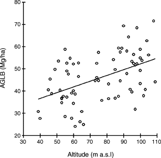

1. [Download : Download full-size image](https://ars.els-cdn.com/content/image/1-s2.0-S0378112706004361-gr4.gif)

## 4. Discussion

### 4.1. Effects of soil and topography on aboveground tree live biomass

Laurance et al. (1999) attributed the great spatial variation on AGLB estimates to nitrogen availability. However, we excluded this element from our analyses and obtained similar results suggesting that tree live biomass might not be limited by nitrogen. Tropical plants play a vital role in controlling nutrient losses. Plants act as source of nutrients (deposition of litter) and sink of nutrients by increasing nutrient sequestration when they are more available. Higher tree biomass could provide more litter, resulting in a positive relationship between biomass and nutrients; higher biomass could also be the result of more nutrient availability. Plants have the potential to affect nutrient levels, to which they respond. Luizão et al. (2004) found a significant difference between soil total nitrogen and nitrogen leaf concentration and topographic positions in central Amazonia. Plateau and slope areas had more nitrogen in the topsoil and leaves than *baixio* areas, emphasizing the close relationship between the amount of nitrogen in the soil and in living tissues. This also could indicate that the rates of decomposition and mineralization are perhaps slower on sandy soils.

Soil and topography could also indirectly affect AGLB variation through changes in species composition, forest dynamics, and physiological constraints driven by soil and topography. Several studies have described the effects of soil and topography on the distribution of trees (Lescure and Boulet, 1985, Sabatier et al., 1997, Clark et al., 1999, Tuomisto et al., 2003) and understory plants (Kinupp and Magnusson, 2005, Costa et al., 2005). If species characterized by large individuals were associated with a particular soil type, this pattern will be related to forest biomass (Fearnside and Leal Filho, 2001). Any effect of soil on the occurrence of emergent species could have a large effect on plot AGLB estimates, because few large individuals can account for a large portion of the plot's AGLB (Brown and Lugo, 1992, Clark and Clark, 1996). This seems to be the case at Ducke, where bigger trees were more frequent in high and flat areas dominated by clay soils.

Differences in forest biomass can also be imposed by physiological constraints of soil and topography. In general, higher forest biomass is expected on more fertile soils, independent of species composition, simply because there are more resources available for plant growth. However, Silva et al. (2002) studied the growth rates of trees along a topographic gradient in central Amazonia and did not detect a topographic influence on growth rate.

It is difficult to establish causal relationships between topography and biomass because topography is a composite variable that covaries with other variables such as soil type (Chauvel et al., 1987), canopy openness (Robert, 2003) and soil water potential (Becker et al., 1988, Daws et al., 2002). Topography also affects forest dynamics (Gale and Barfod, 1999, Bellingham and Tanner, 2000) and nutrient cycling (Luizão et al., 2004). There is some evidence that topography affects the frequency of gaps (Bellingham and Tanner, 2000) and the way trees die (Gale and Barfod, 1999). Therefore, the AGLB variation could represent variation in the natural disturbance regime of the forest. The topographic effects on tree biomass accumulation described here are certainly not due the topography *per se*, but to environmental conditions defined by the topography.

In contrast to our results, AGLB estimates from other tropical forests were insensitive to soil type and/or topography (Clark and Clark, 2000, Chave et al., 2001, Chave et al., 2003). However, most studies were not specifically designed to address soil or topographic effects on AGLB estimates. Results from Panama (Chave et al., 2003) and French Guiana (Chave et al., 2001) were from large and continuous plots (50 and 20 ha, respectively) that could be biased by site selection and too large to detect gradients along the catena.

### 4.2. The contribution of palms to aboveground live biomass estimates

Although palms are conspicuous components of tropical forests, they are frequently excluded from AGLB assessments or are treated as trees (e.g. Laurance et al., 1999), mostly because general palm allometric equations are scarce (e.g. Saldarriaga et al., 1988, Cummings et al., 2002) or species-specific (e.g. Frangi and Lugo, 1985, Hughes et al., 1999). In contrast to trees, most palms change little in diameter while growing in height. The use of tree equations probably overestimates palm biomass, but this should have a modest effect on total estimates (Clark and Clark, 2000), since palms are a relatively minor component of AGLB. In our study, palms represented less than 1% of AGLB estimates per plot. However, palm biomass was highly variable between plots and, in some plots, the biomass of palms represented 10% of the total biomass. Palm biomass also varies between forest types (Cummings et al., 2002) and sites (Clark and Clark, 2000, DeWalt and Chave, 2004). Fearnside (1994) suggested that palms generally contribute about 3.5% of the aboveground biomass in the Brazilian Amazon. At large spatial scales, forests dominated by large palms covered about 20% of the original forest area in the Brazilian Amazon (IBGE, 1997). This means that, at least in some areas, arborescent palms are especially abundant, and make up large proportions of the aboveground live biomass.

Considering palms separately from other life forms should be useful to better understand the structural differences between tropical forests and the role of non-tree components in models of carbon balance in changing landscapes (Brown and Lugo, 1992). It is possible that the high palm biomass in certain areas will affect nutrient cycling processes, such as decomposition rates. Palm leaves on the ground decompose slowly, while palm trunks decompose faster than tree boles (Frangi and Lugo, 1985) and this could potentially affect the carbon cycle.

In this study, we only sampled stemmed palms. Stemless palms are very common in understory of forest around Manaus and, on average, represent 0.4% of AGLB (Nascimento and Laurance, 2002).

### 4.3. Comparing results with other studies

The shape of the plot apparently had little influence on our estimate of the aboveground live biomass in terra-firme forests around Manaus. In this region, both studies (Laurance et al., 1999, this study) dealing with large-scale variation in aboveground live biomass produced similar results, despite using different methodologies. Laurance et al. (1999) used 65 1-ha square plots, obtaining an AGLB mean value of 356 ± 47 Mg/ha, while in this study we used 72 1-ha thin plots that followed topographic contours and obtained an AGLB mean value of 328 ± 41.9 Mg/ha. A study comparing the effect of different methodologies (circular plots vs. square plots) found a 10–16% difference in basal area and aboveground live biomass estimates between the methods, but the authors considered that those differences were likely to be due to measurement protocols rather than the form of the plot (Clark and Clark, 2000). The results of our study and those of Laurance et al. (1999) indicate that different plot shapes can produce similar estimates when tree-measurement protocols and allometric regressions are similar. Although the allometric regressions (Santos, 1996) used by Laurance et al. (1999) make higher biomass estimates for trees over 90 cm dbh, those equations probably make lower biomass estimates for medium size trees, and some sort of compensation may have acted to level off the overall estimates (B. Nelson, pers. comm.).

In this study, we investigated a more complete soil textural gradient than Laurance et al. (1999). However, after excluding one outlier, we found similar results to those of Laurance et al. (1999). The outlying plot presented the lowest biomass of our sample and one of the extremes of the soil gradient investigated. It had much sandier soil than any plot studied by Laurance et al. (1999), but also may have had a much higher water table. This result indicates a greater variation in AGLB biomass than that due simply to soil texture, and future studies should investigate other variables, such as soil drainage, that may inhibit AGLB accumulation.

### 4.4. Implications for regional biomass estimates

The relationships between soil, topography and AGLB estimates could improve our predictions of the responses of the forest to natural or anthropogenic perturbations. This could generate differences in carbon fluxes between patches of soil types, even when carbon stocks are similar between areas (Clark and Clark, 2000). Therefore, long-term biomass dynamics could depend on soil and topographic variation, at least in central Amazonia.

At present, it is not easy to use the relationship between biomass and soils to predict AGLB in other areas. The spatial variability of soil properties in the Amazon region, although recognized, has not been well documented or mapped at high resolution (Richter and Babbar, 1991). This creates problems for extrapolating results from plot-level studies to estimate effects over large areas (Holmes et al., 2004). However, this study showed that topography could be used as a proxy for soil texture in central Amazonia, where the effects of soil and AGLB spatial variation are well documented (Laurance et al., 1999; this study). Topographic variables (altitude and slope) can be obtained from maps, or using digital elevation models (DEM) derived from SRTM radar. As an alternative to soil variables, topography could be used to predict aboveground live biomass over large areas in central Amazonia with almost the same predictive power.

The Amazon forest has an important role in the global carbon budget (Fearnside, 2003), but we still have little data to make reliable predictions. The methodology used at Reserva Ducke is efficient and feasible for long term studies of tree biomass. We believe that similar ongoing studies in other areas (see http://www.ppbio.inpa.gov.br) are an efficient way to improve our knowledge on AGLB spatial variation over the entire Brazilian Amazon.

## Acknowledgements

This work was supported by the Brazilian National Research Council (CNPq) through three grants: a Long Term Ecological Research Project (CNPq/PELD #520039/98-0), CNPq/PNOPG 400033/99-2 and CNPq/IA 467794/00-6. We are grateful to everyone who was involved in field work, especially Benjamim B. da Luz, responsible for setting up the plots, and João Batista da Silva, responsible for tree dbh measurements. Soil data were provided by Eleusa Barros, Regina Luizão, Tania Pimentel and Jane Mertens. C.V. Castilho and R.N.O. de Araújo received fellowships from CNPq to conduct this study. C.T. Paine, B. Nelson and two anonymous referees provided valuable comments on the manuscript.

## Appendix A.

Total AGLB (tree + palm) estimates and topographic features of each one of the 72 permanent plots installed at Reserva Ducke, Manaus, Brazil. The estimates were based on plots with 1-ha of planar area. Soil data are available in http://ppbio.inpa.gov.br/Port/inventarios/ducke/.

| Plot code | Total AGLB (Mg/ha) | Tree AGLB (Mg/ha) | Palm AGLB (Mg/ha) | Slope angle (°) | Altitude (m a.s.l.) | Ground area (ha) |
| --- | --- | --- | --- | --- | --- | --- |
| LO2T0 | 211.0 | 189.8 | 21.2 | 2.0 | 61 | 1.00 |
| LO9T500 | 229.0 | 226.0 | 3.1 | 17.0 | 60 | 1.05 |
| LO4T1500 | 254.7 | 245.0 | 9.7 | 10.7 | 55 | 1.02 |
| LO2T4500 | 271.1 | 269.8 | 1.3 | 25.8 | 65 | 1.11 |
| LO8T6500 | 274.4 | 273.1 | 1.3 | 12.3 | 47 | 1.02 |
| LO1T7500 | 274.5 | 274.3 | 0.2 | 15.3 | 54 | 1.04 |
| LO6T7500 | 277.2 | 276.2 | 1.0 | 22.0 | 60 | 1.08 |
| LO9T6500 | 282.8 | 280.4 | 2.4 | 4.0 | 96 | 1.00 |
| LO5T7500 | 287.2 | 284.0 | 3.2 | 17.3 | 39 | 1.05 |
| LO5T5500 | 290.1 | 289.3 | 0.8 | 5.5 | 60 | 1.00 |
| LO6T500 | 291.5 | 291.4 | 0.2 | 26.3 | 64 | 1.12 |
| LO9T4500 | 295.1 | 294.4 | 0.6 | 17.8 | 85 | 1.05 |
| LO3T7500 | 295.7 | 295.0 | 0.7 | 4.0 | 51 | 1.00 |
| LO7T2500 | 296.0 | 295.1 | 1.0 | 13.0 | 101 | 1.03 |
| LO8T7500 | 296.7 | 295.1 | 1.6 | 4.3 | 95 | 1.00 |
| LO4T6500 | 299.0 | 298.2 | 0.8 | 11.3 | 66 | 1.02 |
| LO6T5500 | 300.7 | 300.4 | 0.3 | 26.8 | 77 | 1.12 |
| LO8T5500 | 300.7 | 299.1 | 1.6 | 0.7 | 97 | 1.00 |
| LO2T6500 | 300.8 | 300.7 | 0.1 | 10.7 | 59 | 1.02 |
| LO6T2500 | 300.9 | 291.5 | 9.3 | 2.7 | 60 | 1.00 |
| LO7T4500 | 302.0 | 301.7 | 0.3 | 2.0 | 100 | 1.00 |
| LO3T1500 | 302.3 | 302.1 | 0.2 | 8.3 | 61 | 1.01 |
| LO6T1500 | 302.5 | 297.5 | 4.9 | 21.8 | 53 | 1.08 |
| LO8T500 | 303.4 | 294.8 | 8.6 | 4.8 | 52 | 1.00 |
| LO9T5500 | 309.6 | 307.9 | 1.7 | 14.8 | 57 | 1.03 |
| LO7T500 | 309.8 | 309.1 | 0.7 | 13.3 | 58 | 1.03 |
| LO7T7500 | 310.1 | 309.8 | 0.3 | 27.0 | 63 | 1.12 |
| LO3T3500 | 310.1 | 295.0 | 15.2 | 10.2 | 55 | 1.02 |
| LO4T3500 | 310.5 | 309.7 | 0.8 | 4.0 | 105 | 1.00 |
| LO7T1500 | 312.0 | 309.0 | 3.0 | 17.7 | 84 | 1.05 |
| LO9T7500 | 314.1 | 312.7 | 1.4 | 4.2 | 97 | 1.00 |
| LO2T2000 | 314.5 | 314.2 | 0.3 | 17.8 | 75 | 1.05 |
| LO6T6500 | 315.1 | 314.6 | 0.6 | 17.2 | 53 | 1.05 |
| LO3T2500 | 318.6 | 317.7 | 0.9 | 10.3 | 53 | 1.02 |
| LO3T500 | 318.6 | 316.8 | 1.8 | 12.3 | 81 | 1.02 |
| LO7T5500 | 321.8 | 321.7 | 0.0 | 0.8 | 100 | 1.00 |
| LO1T5500 | 328.2 | 328.2 | 0.0 | 20.0 | 74 | 1.06 |
| LO2T3000 | 329.8 | 329.1 | 0.7 | 19.7 | 81 | 1.06 |
| LO5T1500 | 333.5 | 330.6 | 2.9 | 10.5 | 93 | 1.02 |
| LO3T6500 | 333.9 | 327.3 | 6.6 | 9.3 | 40 | 1.01 |
| LO6T4500 | 334.2 | 333.7 | 0.5 | 14.0 | 75 | 1.03 |
| LO1T0 | 334.6 | 334.1 | 0.6 | 22.3 | 85 | 1.08 |
| LO4T2500 | 336.3 | 334.6 | 1.7 | 6.8 | 100 | 1.01 |
| LO4T500 | 337.0 | 337.0 | 0.1 | 2.2 | 46 | 1.00 |
| LO8T3500 | 338.4 | 333.9 | 4.5 | 5.2 | 56 | 1.00 |
| LO2T7500 | 339.9 | 339.5 | 0.4 | 6.8 | 45 | 1.01 |
| LO5T3500 | 341.4 | 340.7 | 0.7 | 0.7 | 103 | 1.00 |
| LO1T6500 | 342.7 | 341.8 | 0.8 | 19.2 | 59 | 1.06 |
| LO7T6500 | 347.1 | 346.6 | 0.6 | 8.7 | 95 | 1.01 |
| LO4T7500 | 347.6 | 347.5 | 0.2 | 1.0 | 88 | 1.00 |
| LO8T2500 | 349.0 | 347.1 | 1.9 | 10.0 | 63 | 1.02 |
| LO3T5500 | 349.2 | 348.8 | 0.4 | 21.7 | 74 | 1.08 |
| LO4T4500 | 351.0 | 350.8 | 0.2 | 1.5 | 98 | 1.00 |
| LO6T3500 | 351.4 | 349.7 | 1.7 | 8.3 | 100 | 1.01 |
| LO4T5500 | 353.4 | 352.9 | 0.5 | 0.7 | 92 | 1.00 |
| LO9T2500 | 353.6 | 353.4 | 0.1 | 9.0 | 87 | 1.01 |
| LO5T2500 | 353.8 | 353.3 | 0.4 | 9.5 | 73 | 1.01 |
| LO5T4500 | 353.9 | 353.8 | 0.1 | 3.7 | 94 | 1.00 |
| LO5T500 | 356.1 | 345.9 | 10.2 | 3.3 | 56 | 1.00 |
| LO2T5500 | 366.3 | 365.8 | 0.5 | 0.5 | 96 | 1.00 |
| LO8T1500 | 371.3 | 368.8 | 2.5 | 5.7 | 49 | 1.00 |
| LO9T1500 | 378.0 | 376.7 | 1.3 | 11.2 | 87 | 1.02 |
| LO5T6500 | 379.6 | 379.2 | 0.3 | 2.2 | 90 | 1.00 |
| LO8T4500 | 382.1 | 379.6 | 2.4 | 2.0 | 102 | 1.00 |
| LO7T3500 | 382.6 | 382.1 | 0.5 | 4.8 | 92 | 1.00 |
| LO1T4000 | 389.2 | 389.2 | 0.0 | 7.2 | 89 | 1.01 |
| LO1T2000 | 396.3 | 395.4 | 0.9 | 2.2 | 109 | 1.00 |
| LO1T1000 | 396.5 | 395.3 | 1.2 | 0.8 | 108 | 1.00 |
| LO3T4500 | 400.0 | 399.4 | 0.6 | 9.5 | 88 | 1.01 |
| LO2T1000 | 410.3 | 409.3 | 1.1 | 14.3 | 98 | 1.03 |
| LO1T3000 | 422.3 | 419.6 | 2.7 | 4.7 | 104 | 1.00 |
| LO9T3500 | 426.3 | 422.8 | 3.5 | 4.3 | 56 | 1.00 |

## References

1. Becker et al., 1988

   P. Becker, P.E. Rabenold, J.R. Idol, A.P. Smith

   Water potential gradients for gaps and slopes in a Panamanian tropical moist forest's dry season

   J. Trop. Ecol., 4 (1988), pp. 173-184

   Google Scholar
2. Bellingham and Tanner, 2000

   P.J. Bellingham, E.V.J. Tanner

   The influence of topography on tree growth, mortality, and recruitment in a tropical Montane Forest

   Biotropica, 32 (3) (2000), pp. 378-384

   Google Scholar
3. Bravard and Righi, 1989

   S. Bravard, D. Righi

   Geochemical differences in an oxisol-spodosol toposequence of Amazônia

   Brazil Geoderma., 44 (1989), pp. 29-42

   [View PDF](https://www.sciencedirect.com/science/article/pii/0016706189900049/pdf?md5=c8f700ffeb57da519d3ccd51aa799e06&pid=1-s2.0-0016706189900049-main.pdf)[View article](https://www.sciencedirect.com/science/article/pii/0016706189900049)[View in Scopus](https://www.scopus.com/inward/record.url?eid=2-s2.0-0024527323&partnerID=10&rel=R3.0.0)[Google Scholar](https://scholar.google.com/scholar_lookup?title=Geochemical%20differences%20in%20an%20oxisol-spodosol%20toposequence%20of%20Amaz%C3%B4nia&publication_year=1989&author=S.%20Bravard&author=D.%20Righi)
4. Brown, 1997

   Brown, S., 1997. Estimating biomass and biomass change of tropical forests: a prime. FAO Forestry Paper 134, Rome, Italy.

   [Google Scholar](https://scholar.google.com/scholar?q=Brown%2C%20S.%2C%201997.%20Estimating%20biomass%20and%20biomass%20change%20of%20tropical%20forests%3A%20a%20prime.%20FAO%20Forestry%20Paper%20134%2C%20Rome%2C%20Italy.)
5. Brown and Lugo, 1992

   S. Brown, A.E. Lugo

   Aboveground biomass estimates for tropical moist forests of the Brazilian Amazon

   Interciencia, 17 (1) (1992), pp. 8-18

   [View in Scopus](https://www.scopus.com/inward/record.url?eid=2-s2.0-0002495131&partnerID=10&rel=R3.0.0)[Google Scholar](https://scholar.google.com/scholar_lookup?title=Aboveground%20biomass%20estimates%20for%20tropical%20moist%20forests%20of%20the%20Brazilian%20Amazon&publication_year=1992&author=S.%20Brown&author=A.E.%20Lugo)
6. Chauvel et al., 1987

   A. Chauvel, Y. Lucas, R. Boulet

   On the genesis of the soil mantle of the region of Manaus, central Amazonia, Brazil

   Experientia, 43 (1987), pp. 234-241

   [View in Scopus](https://www.scopus.com/inward/record.url?eid=2-s2.0-0006235262&partnerID=10&rel=R3.0.0)Google Scholar
7. Chave et al., 2004

   J. Chave, R. Condit, S. Aguilar, A. Hernandez, S. Lao, R. Perez

   Error propagation and scaling for tropical forest biomass estimates

   Phil. Trans. R. Soc. London B, 359 (2004), pp. 409-420

   [View in Scopus](https://www.scopus.com/inward/record.url?eid=2-s2.0-1642316415&partnerID=10&rel=R3.0.0)Google Scholar
8. Chave et al., 2003

   J. Chave, R. Condit, S. Lao, J.P. Caspersen, R.B. Foster, S.P. Hubbell

   Spatial and temporal variation of biomass in a tropical forest: results from a large census plot in Panama

   J. Ecol., 91 (2003), pp. 240-252

   [View in Scopus](https://www.scopus.com/inward/record.url?eid=2-s2.0-0037394558&partnerID=10&rel=R3.0.0)Google Scholar
9. Chave et al., 2001

   J. Chave, B. Riéra, M. Dubois

   Estimation of biomass in a neotropical forest of French Guiana: spatial and temporal variability

   J. Trop. Ecol., 17 (2001), pp. 79-96

   [View in Scopus](https://www.scopus.com/inward/record.url?eid=2-s2.0-0035125750&partnerID=10&rel=R3.0.0)Google Scholar
10. Clark, 2002

    D.A. Clark

    Are tropical forests an important carbon sink? Reanalysis of the long-term plot data

    Ecol. Appl., 12 (1) (2002), pp. 3-7

    [View in Scopus](https://www.scopus.com/inward/record.url?eid=2-s2.0-0036162605&partnerID=10&rel=R3.0.0)[Google Scholar](https://scholar.google.com/scholar_lookup?title=Are%20tropical%20forests%20an%20important%20carbon%20sink%20Reanalysis%20of%20the%20long-term%20plot%20data&publication_year=2002&author=D.A.%20Clark)
11. Clark and Clark, 1996

    D.B. Clark, D.A. Clark

    Abundance, growth and mortality of very large trees in neotropical lowland rain forest

    Forest Ecol. Manage., 80 (1996), pp. 235-244

    [View PDF](https://www.sciencedirect.com/science/article/pii/0378112795036075/pdf?md5=abcdd18fa9dc979b39e69cf63594e882&pid=1-s2.0-0378112795036075-main.pdf)[View article](https://www.sciencedirect.com/science/article/pii/0378112795036075)[View in Scopus](https://www.scopus.com/inward/record.url?eid=2-s2.0-0029668091&partnerID=10&rel=R3.0.0)Google Scholar
12. Clark and Clark, 2000

    D.B. Clark, D.A. Clark

    Landscape-scale variation in forest structure and biomass in a tropical rain forest

    Forest Ecol. Manage., 137 (2000), pp. 185-198

    [View PDF](https://www.sciencedirect.com/science/article/pii/S0378112799003278/pdfft?md5=e8ce98199c82202995fff4df393b0d1f&pid=1-s2.0-S0378112799003278-main.pdf)[View article](https://www.sciencedirect.com/science/article/pii/S0378112799003278)[View in Scopus](https://www.scopus.com/inward/record.url?eid=2-s2.0-0034668238&partnerID=10&rel=R3.0.0)Google Scholar
13. Clark et al., 1999

    D.B. Clark, M.W. Palmer, D.A. Clark

    Edaphic factors and the landscape-scale distribution of tropical rain forest trees

    Ecology, 80 (8) (1999), pp. 2662-2675

    [View in Scopus](https://www.scopus.com/inward/record.url?eid=2-s2.0-0033452158&partnerID=10&rel=R3.0.0)Google Scholar
14. Costa et al., 2005

    F.C.R. Costa, W.E. Magnusson, R.C. Luizão

    Mesoscale distribution of Amazonian understorey herbs in relation to topography, soil and watersheds

    J. Ecol., 93 (2005), pp. 863-878

    [CrossRef](https://doi.org/10.1111/j.1365-2745.2005.01020.x)[View in Scopus](https://www.scopus.com/inward/record.url?eid=2-s2.0-33745028273&partnerID=10&rel=R3.0.0)Google Scholar
15. Cummings et al., 2002

    D.L. Cummings, J.B. Kauffman, D.A. Perry, R.F. Hughes

    Aboveground biomass and structure of rainforests in the southwestern Brazilian Amazon

    Forest Ecol. Manage., 163 (2002), pp. 293-307

    [View PDF](https://www.sciencedirect.com/science/article/pii/S0378112701005874/pdfft?md5=2af5518c9ed3aa0940311b2ab3916421&pid=1-s2.0-S0378112701005874-main.pdf)[View article](https://www.sciencedirect.com/science/article/pii/S0378112701005874)[View in Scopus](https://www.scopus.com/inward/record.url?eid=2-s2.0-0037188953&partnerID=10&rel=R3.0.0)Google Scholar
16. Daws et al., 2002

    M.I. Daws, C.E. Mullins, D.F.R.P. Burslem, S.R. Paton, J.W. Dalling

    Topographic position affects the water regime in a semideciduous tropical forest in Panamá

    Plant Soil, 238 (2002), pp. 79-90

    [View in Scopus](https://www.scopus.com/inward/record.url?eid=2-s2.0-0036123964&partnerID=10&rel=R3.0.0)Google Scholar
17. DeWalt and Chave, 2004

    S.J. DeWalt, J. Chave

    Structure and biomass of four lowland neotropical forests

    Biotropica, 36 (1) (2004), pp. 7-19

    [View in Scopus](https://www.scopus.com/inward/record.url?eid=2-s2.0-1542367610&partnerID=10&rel=R3.0.0)[Google Scholar](https://scholar.google.com/scholar_lookup?title=Structure%20and%20biomass%20of%20four%20lowland%20neotropical%20forests&publication_year=2004&author=S.J.%20DeWalt&author=J.%20Chave)
18. EMBRAPA, 1997

    EMBRAPA

    Manual de Métodos de Análises de Solos. Centro Nacional de Pesquisas de Solo. SBLCS

    Rio de Janeiro (1997)

    [Google Scholar](https://scholar.google.com/scholar_lookup?title=Manual%20de%20M%C3%A9todos%20de%20An%C3%A1lises%20de%20Solos.%20Centro%20Nacional%20de%20Pesquisas%20de%20Solo.%20SBLCS&publication_year=1997&author=EMBRAPA)
19. Fearnside, 1994

    P.M. Fearnside

    Biomassa das florestas Amazônicas brasileiras

    Emissão × seqüestro de CO<sub>2</sub>: uma oportunidade de negócios para o Brasil, Companhia Vale do Rio Doce, Rio de Janeiro, Brasil (1994), pp. 95-124

    [Google Scholar](https://scholar.google.com/scholar_lookup?title=Biomassa%20das%20florestas%20Amaz%C3%B4nicas%20brasileiras&publication_year=1994&author=P.M.%20Fearnside)
20. Fearnside, 1996

    P.M. Fearnside

    Amazonian deforestation and global warming: carbon stocks in vegetation replacing Brazil's Amazon forest

    Forest Ecol. Manage., 80 (1996), pp. 21-34

    [View PDF](https://www.sciencedirect.com/science/article/pii/0378112795036474/pdf?md5=ee362c8f37bf66a4d8c5b46c8ae4d447&pid=1-s2.0-0378112795036474-main.pdf)[View article](https://www.sciencedirect.com/science/article/pii/0378112795036474)[View in Scopus](https://www.scopus.com/inward/record.url?eid=2-s2.0-0029667211&partnerID=10&rel=R3.0.0)Google Scholar
21. Fearnside, 2003

    P.M. Fearnside

    A Floresta Amazônica nas Mudanças Globais

    INPA, Manaus, Amazonas (2003)

    [Google Scholar](https://scholar.google.com/scholar_lookup?title=A%20Floresta%20Amaz%C3%B4nica%20nas%20Mudan%C3%A7as%20Globais&publication_year=2003&author=P.M.%20Fearnside)
22. Fearnside and Leal Filho, 2001

    P.M. Fearnside, N. Leal Filho

    Soil and development in Amazonia: lessons from the biological dynamics of forest fragment project

    R. Bierregaard Jr., C. Gascon, T.E. Lovejoy, R.C.G. Mesquita (Eds.), Lessons from Amazonia: The Ecology and Conservation of a Fragmented Forest, Yale University Press, New Haven (2001), pp. 291-312

    Google Scholar
23. Frangi and Lugo, 1985

    J.L. Frangi, A.E. Lugo

    Ecosystem dynamics of a subtropical floodplain forest

    Ecol. Monogr., 55 (3) (1985), pp. 351-369

    [CrossRef](https://doi.org/10.2307/1942582)[Google Scholar](https://scholar.google.com/scholar_lookup?title=Ecosystem%20dynamics%20of%20a%20subtropical%20floodplain%20forest&publication_year=1985&author=J.L.%20Frangi&author=A.E.%20Lugo)
24. Gale and Barfod, 1999

    N. Gale, A.S. Barfod

    Canopy tree mode of death in a western Ecuadorian rain forest

    J. Trop. Ecol., 15 (1999), pp. 415-436

    [View in Scopus](https://www.scopus.com/inward/record.url?eid=2-s2.0-0032769193&partnerID=10&rel=R3.0.0)[Google Scholar](https://scholar.google.com/scholar_lookup?title=Canopy%20tree%20mode%20of%20death%20in%20a%20western%20Ecuadorian%20rain%20forest&publication_year=1999&author=N.%20Gale&author=A.S.%20Barfod)
25. Henderson and Scariot, 1993

    A. Henderson, A. Scariot

    A flórula da Reserva Ducke, I: Palmae (Arecaceae)

    Acta Amazon., 23 (4) (1993), pp. 349-370

    [CrossRef](https://doi.org/10.1590/1809-43921993234369)[Google Scholar](https://scholar.google.com/scholar_lookup?title=A%20fl%C3%B3rula%20da%20Reserva%20Ducke%2C%20I%3A%20Palmae%20&publication_year=1993&author=A.%20Henderson&author=A.%20Scariot)
26. Higuchi et al., 1998

    N. Higuchi, J.D. Santos, R.J. Ribeiro, L. Minette, Y. Biot

    Biomassa da parte aérea da vegetação da floresta tropical úmida de terra-firme da Amazônia Brasileira

    Acta Amazon., 28 (1998), pp. 153-166

    [CrossRef](https://doi.org/10.1590/1809-43921998282166)Google Scholar
27. Holmes et al., 2004

    K.W. Holmes, D.A. Roberts, S. Sweeney, I. Numata, E. Matricardi, T.W. Biggs, G. Batista, O.A. Chadwick

    Soil databases and the problem of establishing regional biogeochemical trends

    Global Change Biol., 10 (2004), pp. 796-814

    [View in Scopus](https://www.scopus.com/inward/record.url?eid=2-s2.0-2642539388&partnerID=10&rel=R3.0.0)Google Scholar
28. Houghton, 2005

    R.A. Houghton

    Aboveground forest biomass and the global carbon balance

    Global Change Biol., 11 (2005), pp. 945-958

    [CrossRef](https://doi.org/10.1111/j.1365-2486.2005.00955.x)[View in Scopus](https://www.scopus.com/inward/record.url?eid=2-s2.0-20844459799&partnerID=10&rel=R3.0.0)[Google Scholar](https://scholar.google.com/scholar_lookup?title=Aboveground%20forest%20biomass%20and%20the%20global%20carbon%20balance&publication_year=2005&author=R.A.%20Houghton)
29. Houghton et al., 2001

    R.A. Houghton, K.T. Lawrence, J.L. Hackler, S. Brown

    The spatial distribution of forest biomass in the Brazilian Amazon: a comparison of estimates

    Global Change Biol., 7 (2001), pp. 731-746

    [View in Scopus](https://www.scopus.com/inward/record.url?eid=2-s2.0-0034783125&partnerID=10&rel=R3.0.0)Google Scholar
30. Hughes et al., 1999

    R.F. Hughes, J.B. Kauffman, V.J. Jaramillo

    Biomass, carbon, and nutrient dynamics of secondary forests in a humid tropical region of México

    Ecology, 80 (6) (1999), pp. 1892-1907

    [View in Scopus](https://www.scopus.com/inward/record.url?eid=2-s2.0-0032873722&partnerID=10&rel=R3.0.0)Google Scholar
31. IBGE, 1997

    IBGE

    Diagnóstico Ambiental da Amazônia Legal

    IBGE, Rio de Janeiro (1997)

    (CD-Rom)

    [Google Scholar](https://scholar.google.com/scholar_lookup?title=Diagn%C3%B3stico%20Ambiental%20da%20Amaz%C3%B4nia%20Legal&publication_year=1997&author=IBGE)
32. Keller et al., 2001

    M. Keller, M. Palace, G. Hurtt

    Biomass estimation in the Tapajós National Forest, Brazil. Examination of sampling and allometric uncertainties

    Forest Ecol. Manage., 154 (2001), pp. 371-382

    [View PDF](https://www.sciencedirect.com/science/article/pii/S0378112701005096/pdfft?md5=099dba29f7ca5cde11f9185b9a27e7de&pid=1-s2.0-S0378112701005096-main.pdf)[View article](https://www.sciencedirect.com/science/article/pii/S0378112701005096)[View in Scopus](https://www.scopus.com/inward/record.url?eid=2-s2.0-0035575467&partnerID=10&rel=R3.0.0)Google Scholar
33. Kinupp and Magnusson, 2005

    V.F. Kinupp, W.E. Magnusson

    Spatial patterns in the understory shrub genus *Psychotria* in central Amazonia: effects of distance and topography

    J. Trop. Ecol., 21 (2005), pp. 363-374

    [View in Scopus](https://www.scopus.com/inward/record.url?eid=2-s2.0-22744451216&partnerID=10&rel=R3.0.0)Google Scholar
34. Körner, 2003

    C. Körner

    Slow in, rapid out—carbon flux studies and Kyoto targets

    Science, 300 (2003), pp. 1242-1243

    [View in Scopus](https://www.scopus.com/inward/record.url?eid=2-s2.0-0038187681&partnerID=10&rel=R3.0.0)[Google Scholar](https://scholar.google.com/scholar_lookup?title=Slow%20in%2C%20rapid%20outcarbon%20flux%20studies%20and%20Kyoto%20targets&publication_year=2003&author=C.%20K%C3%B6rner)
35. Laurance, 2001

    W.F. Laurance

    The hyper-diverse flora of the Central Amazon: an overview

    R. Bierregaard Jr., C. Gascon, T.E. Lovejoy, R.C.G. Mesquita (Eds.), Lessons from Amazonia: The Ecology and Conservation of a Fragmented Forest, Yale University Press, New Haven (2001), pp. 47-53

    [Google Scholar](https://scholar.google.com/scholar_lookup?title=The%20hyper-diverse%20flora%20of%20the%20Central%20Amazon%3A%20an%20overview&publication_year=2001&author=W.F.%20Laurance)
36. Laurance et al., 1999

    W.F. Laurance, P.M. Fearnside, S.G. Laurance, P. Delamonica, T.E. Lovejoy, J.M. Rankin-de-Merona, J. Chambers, C. Gascon

    Relationship between soils and Amazon forest biomass: a landscape-scale study

    Forest Ecol. Manage., 118 (1999), pp. 127-138

    [View PDF](https://www.sciencedirect.com/science/article/pii/S0378112798004940/pdfft?md5=9bcf1270f632e0ec30862d0c961aa5ee&pid=1-s2.0-S0378112798004940-main.pdf)[View article](https://www.sciencedirect.com/science/article/pii/S0378112798004940)[View in Scopus](https://www.scopus.com/inward/record.url?eid=2-s2.0-0033553790&partnerID=10&rel=R3.0.0)Google Scholar
37. Lescure and Boulet, 1985

    J.-P. Lescure, R. Boulet

    Relationships between soil and vegetation in a tropical rain forest in French Guiana

    Biotropica, 17 (2) (1985), pp. 155-164

    [CrossRef](https://doi.org/10.2307/2388508)[View in Scopus](https://www.scopus.com/inward/record.url?eid=2-s2.0-0022169565&partnerID=10&rel=R3.0.0)Google Scholar
38. Luizão et al., 2004

    R.C.C. Luizão, F.J. Luizão, R.Q. Paiva, T.F. Monteiro, L.S. Sousa, B. Kruijt

    Variation of carbon and nitrogen cycling processes along a topographic gradient in a Central Amazonian forest

    Global Change Biol., 10 (2004), pp. 592-600

    [View in Scopus](https://www.scopus.com/inward/record.url?eid=2-s2.0-2642548308&partnerID=10&rel=R3.0.0)Google Scholar
39. Magnusson et al., 2005

    W.E. Magnusson, A.P. Lima, R. Luizão, F. Luizão, F.R.C. Costa, C.V. Castilho, V.F. Kinupp

    RAPELD: A modification of the Gentry method for biodiversity surveys in long-term ecological research sites

    Biota Neotrop., 5 (2) (2005), pp. 1-6

    Google Scholar
40. Malhi and Grace, 2000

    Y. Malhi, J. Grace

    Tropical forests and atmospheric carbon dioxide

    Trends Ecol. Evol., 15 (8) (2000), pp. 332-337

    [View PDF](https://www.sciencedirect.com/science/article/pii/S0169534700019066/pdfft?md5=c8e920886b5856d290d215b6b50e423a&pid=1-s2.0-S0169534700019066-main.pdf)[View article](https://www.sciencedirect.com/science/article/pii/S0169534700019066)[View in Scopus](https://www.scopus.com/inward/record.url?eid=2-s2.0-0034256013&partnerID=10&rel=R3.0.0)[Google Scholar](https://scholar.google.com/scholar_lookup?title=Tropical%20forests%20and%20atmospheric%20carbon%20dioxide&publication_year=2000&author=Y.%20Malhi&author=J.%20Grace)
41. Marques-Filho et al., 1981

    A.O. Marques-Filho, M.N.G. Ribeiro, J.M. Santos

    Estudos climatológicos da Reserva Florestal Ducke, Manaus, AM. IV-precipitação

    Acta Amazon., 4 (1981), pp. 759-768

    [CrossRef](https://doi.org/10.1590/1809-43921981114759)Google Scholar
42. Mathieu and Pieltain, 1998

    C. Mathieu, F. Pieltain

    Analyse physique des sols: méthodes choisies

    Lavoisier, Paris (1998)

    [Google Scholar](https://scholar.google.com/scholar_lookup?title=Analyse%20physique%20des%20sols%3A%20m%C3%A9thodes%20choisies&publication_year=1998&author=C.%20Mathieu&author=F.%20Pieltain)
43. Mertens, 2004

    Mertens, J., 2004. The characterization of selected physical and chemical soil properties of the surface soil layer in the “Reserva Ducke”, Manaus, Brazil, with emphasis on their spatial distribution. Bachelor Thesis. Humboldt-Universität Zu Berlin. Berlin.

    Google Scholar
44. Murphy and Riley, 1962

    J. Murphy, J.P. Riley

    A modified single solution method for the determination of phosphate in natural waters

    Anal. Chim. Acta, 27 (1962), pp. 31-36

    [View PDF](https://www.sciencedirect.com/science/article/pii/S0003267000884445/pdf?md5=4d502d84d84f50995134a24b27f393fd&pid=1-s2.0-S0003267000884445-main.pdf)[View article](https://www.sciencedirect.com/science/article/pii/S0003267000884445)[View in Scopus](https://www.scopus.com/inward/record.url?eid=2-s2.0-34247898040&partnerID=10&rel=R3.0.0)Google Scholar
45. Nascimento and Laurance, 2002

    H.E.M. Nascimento, W.F. Laurance

    Total aboveground biomass in central Amazonian rainforest: a landscape-scale study

    Forest Ecol. Manage., 168 (2002), pp. 311-321

    [View PDF](https://www.sciencedirect.com/science/article/pii/S0378112701007496/pdfft?md5=72c7dbbcd4e67790c4911c5e6ae52245&pid=1-s2.0-S0378112701007496-main.pdf)[View article](https://www.sciencedirect.com/science/article/pii/S0378112701007496)[View in Scopus](https://www.scopus.com/inward/record.url?eid=2-s2.0-0036723043&partnerID=10&rel=R3.0.0)Google Scholar
46. Nelson et al., 1953

    W.L. Nelson, A. Mehlich, E. Winters

    The development, evaluation and use of soil tests for phosphorus availability

    W.H. Pierre, A.F. Norman (Eds.), Soil and Fertilizers, Phosphorus in Crop Nutrition. Aponany Monographs, Academic Press, New York (1953), pp. 153-188

    [View in Scopus](https://www.scopus.com/inward/record.url?eid=2-s2.0-84948307557&partnerID=10&rel=R3.0.0)Google Scholar
47. Ribeiro et al., 1999

    J.E.L.S. Ribeiro, M.G. Hopkins, A. Vicentini, C.A. Sothers, M.A.S. Costa, J.M. Brito, M.A.D. Souza, L.H.P. Martins, L.G. Lohmann, P.A.C.L. Assunção, E.C. Pereira, C.F. Silva, M.R. Mesquita, L. Procópio

    Flora da Reserva Ducke: Guia de Identificação das Plantas Vasculares de uma Floresta de Terra Firme na Amazônia Central

    INPA, Manaus (1999)

    Google Scholar
48. Richter and Babbar, 1991

    D.D. Richter, L.I. Babbar

    Soil diversity in the tropics

    Adv. Ecol. Res., 21 (1991), pp. 315-389

    [View PDF](https://www.sciencedirect.com/science/article/pii/S0065250408601002/pdf?md5=a4a2911d9c8a275cd257a172b7a6dd65&pid=1-s2.0-S0065250408601002-main.pdf)[View article](https://www.sciencedirect.com/science/article/pii/S0065250408601002)[View in Scopus](https://www.scopus.com/inward/record.url?eid=2-s2.0-77956843401&partnerID=10&rel=R3.0.0)[Google Scholar](https://scholar.google.com/scholar_lookup?title=Soil%20diversity%20in%20the%20tropics&publication_year=1991&author=D.D.%20Richter&author=L.I.%20Babbar)
49. Robert, 2003

    A. Robert

    Simulation of the effect of topography and tree falls on stand dynamics and stand structure of tropical forest

    Ecol. Modell., 167 (2003), pp. 287-303

    [View PDF](https://www.sciencedirect.com/science/article/pii/S030438000300200X/pdfft?md5=70c8eb96ebb3c090d224ef0588fcebea&pid=1-s2.0-S030438000300200X-main.pdf)[View article](https://www.sciencedirect.com/science/article/pii/S030438000300200X)[View in Scopus](https://www.scopus.com/inward/record.url?eid=2-s2.0-0346816539&partnerID=10&rel=R3.0.0)Google Scholar
50. Sabatier et al., 1997

    D. Sabatier, M. Grimaldi, M.-F. Prévost, J. Guillaumet, M. Godron, M. Dosso, P. Curmi

    The influence of soil cover organization on the floristic and structural heterogeneity of a Guianan rain forest

    Plant Ecol., 131 (1997), pp. 81-108

    [View in Scopus](https://www.scopus.com/inward/record.url?eid=2-s2.0-0030613444&partnerID=10&rel=R3.0.0)Google Scholar
51. Saldarriaga et al., 1988

    J.G. Saldarriaga, D.C. West, M.L. Tharp, C. Uhl

    Long-term chronosequence of forest succession in the upper Rio Negro of Colombia and Venezuela

    J. Ecol., 76 (1988), pp. 938-958

    [CrossRef](https://doi.org/10.2307/2260625)[View in Scopus](https://www.scopus.com/inward/record.url?eid=2-s2.0-0024179982&partnerID=10&rel=R3.0.0)Google Scholar
52. Santos, 1996

    Santos, J., 1996. Análise de modelos de regressão para estimar a fitomassa de floresta tropical úmida de terra-firme da Amazonia Central. PhD Thesis, Universidade Federal de Viçosa, Minas Gerais, Brasil.

    Google Scholar
53. Sheil, 1995

    D. Sheil

    A critique of permanent plot methods and analysis with examples from Budongo Forest, Uganda

    Forest Ecol. Manage., 77 (1995), pp. 11-34

    [View PDF](https://www.sciencedirect.com/science/article/pii/037811279503583V/pdf?md5=86f2518569fa103ddbf3dee3dd880e33&pid=1-s2.0-037811279503583V-main.pdf)[View article](https://www.sciencedirect.com/science/article/pii/037811279503583V)[View in Scopus](https://www.scopus.com/inward/record.url?eid=2-s2.0-0028984020&partnerID=10&rel=R3.0.0)[Google Scholar](https://scholar.google.com/scholar_lookup?title=A%20critique%20of%20permanent%20plot%20methods%20and%20analysis%20with%20examples%20from%20Budongo%20Forest%2C%20Uganda&publication_year=1995&author=D.%20Sheil)
54. Silva et al., 2002

    R.P. Silva, J. dos Santos, E.S. Tribuzy, J.Q. Chambers, S. Nakamura, N. Higuchi

    Diameter increment and growth patterns for individual trees growing in central Amazon, Brazil

    Forest Ecol. Manage., 166 (2002), pp. 295-301

    [View in Scopus](https://www.scopus.com/inward/record.url?eid=2-s2.0-0036094733&partnerID=10&rel=R3.0.0)Google Scholar
55. Silver et al., 2000

    W.L. Silver, J. Neff, M. McGroddy, E. Veldkamp, M. Keller, R. Cosme

    Effects of soil texture on belowground carbon and nutrient storage in a lowland Amazonian forest ecosystem

    Ecosystem, 3 (2000), pp. 193-209

    [View in Scopus](https://www.scopus.com/inward/record.url?eid=2-s2.0-0034127239&partnerID=10&rel=R3.0.0)Google Scholar
56. Sollins, 1998

    P. Sollins

    Factors influencing species composition in tropical lowland rain forest: does soil matter?

    Ecology, 79 (1) (1998), pp. 23-30

    [View in Scopus](https://www.scopus.com/inward/record.url?eid=2-s2.0-0031714518&partnerID=10&rel=R3.0.0)[Google Scholar](https://scholar.google.com/scholar_lookup?title=Factors%20influencing%20species%20composition%20in%20tropical%20lowland%20rain%20forest%3A%20does%20soil%20matter&publication_year=1998&author=P.%20Sollins)
57. Sombroek, 2000

    W.G. Sombroek

    Amazon land forms and soils in relation to biological diversity

    Acta Amazon., 30 (2000), pp. 81-100

    [CrossRef](https://doi.org/10.1590/1809-43922000301100)[Google Scholar](https://scholar.google.com/scholar_lookup?title=Amazon%20land%20forms%20and%20soils%20in%20relation%20to%20biological%20diversity&publication_year=2000&author=W.G.%20Sombroek)
58. Tuomisto et al., 2003

    H. Tuomisto, K. Ruokolainen, M. Aguilar, A. Sarmiento

    Floristic patterns along a 43-km long transect in an Amazonian rain forest

    J. Ecol., 91 (2003), pp. 743-756

    [View in Scopus](https://www.scopus.com/inward/record.url?eid=2-s2.0-0141924376&partnerID=10&rel=R3.0.0)Google Scholar
59. Wilkinson, 1990

    L. Wilkinson

    SYSTAT: The System for Statistics

    SYSTAT Inc., Evanston, IL, USA (1990)

    [Google Scholar](https://scholar.google.com/scholar_lookup?title=SYSTAT%3A%20The%20System%20for%20Statistics&publication_year=1990&author=L.%20Wilkinson)
60. Zarin et al., 2001

    D.J. Zarin, M.J. Ducey, J.M. Tucker, W.A. Salas

    Potential biomass accumulation in Amazonian regrowth forests

    Ecosystems, 4 (2001), pp. 658-668

    [View in Scopus](https://www.scopus.com/inward/record.url?eid=2-s2.0-0035652090&partnerID=10&rel=R3.0.0)Google Scholar

## Cited by (284)

- 2023, Journal of Tropical Ecology

### [Current status of the Critically Endangered Black-winged Trumpeter Psophia obscura in one of its last strongholds](https://doi.org/10.1017/S0959270922000077)

- 2023, Bird Conservation International

### [Fragmentation is the Main Driver of Residual Forest Aboveground Biomass in West African Low Forest-High Deforestation Landscapes](https://doi.org/10.2139/ssrn.4610676)

- 2023, SSRN

### [The Retrieval of Forest and Grass Fractional Vegetation Coverage in Mountain Regions Based on Spatio-Temporal Transfer Learning](https://doi.org/10.3390/rs15194857)

- 2023, Remote Sensing

### [The relationship between plant diversity and aboveground biomass in managed and unmanaged temperate forests](https://doi.org/10.1007/s10342-023-01583-8)

- 2023, European Journal of Forest Research

[View all citing articles on Scopus](http://www.scopus.com/scopus/inward/citedby.url?partnerID=10&rel=3.0.0&eid=2-s2.0-33748799427&md5=eca25c2b3dc779c5e2bed5ea0e84a)

[View Abstract](https://www.sciencedirect.com/science/article/abs/pii/S0378112706004361)

Copyright © 2006 Elsevier B.V. All rights reserved.

  Kelly Geronazzo Martins, …, Renato Marques

  Akhlaq Amin Wani, …, Ombir Singh

  [View PDF](https://www.sciencedirect.com/science/article/pii/S1574954114001630/pdfft?md5=2f42f6994370d50000f28dd82b2dd525&pid=1-s2.0-S1574954114001630-main.pdf)

  Shiekh Marifatul Haq, …, Anzar Ahmad Khuroo

Citations

Captures

Social Media

- Shares, Likes & Comments: 1

[View details](https://plu.mx/plum/a/?doi=10.1016/j.foreco.2006.06.024&theme=plum-sciencedirect-theme&hideUsage=true)